# Homework 2

#### Author: Quan Yuan

#### UNI: qy2205

## Part I: Loading and Cleaning data in R

#### (1) Load the data into a dataframe called housing.

```r
housing <- read.csv("NYChousing.csv")
```

#### (2) How many rows and columns does the dataframe have?

```r
cat("number of rows", dim(housing)[1])
```

```
## number of rows 2506
```

```r
cat("number of columns", dim(housing)[2])
```

```
## number of columns 22
```

#### (3) Run this command, and explain, in words, what this does

```r
apply(is.na(housing), 2, sum)
```

```
##                            UID                   PropertyName
##                              0                              0
##                            Lon                            Lat
##                             15                             15
##                       AgencyID                           Name
##                              0                              0
##                          Value                        Address
##                             52                              0
##                 Violations2010                     REACNumber
##                              0                           1873
##                        Borough                             CD
##                              0                              0
##            CityCouncilDistrict                    CensusTract
##                             10                              0
##                  BuildingCount                      UnitCount
##                              0                              0
##                      YearBuilt                          Owner
##                              0                              0
##                    Rental.Coop              OwnerProfitStatus
##                              0                              0
##      AffordabilityRestrictions StartAffordabilityRestrictions
##                              0                              5
```

**Answer:** is.na(housing) return a bool matrix(True for nan, False for not nan)  
2 indicates columns, sum means we use sum function apply to each column. The command counts the number of values that are missing in each column.

#### (4) Remove the rows of the dataset for which the variable Value is NA

```r
# row.has.na <- apply(housing, 1, function(x){any(is.na(x))})
# housing <- housing[!row.has.na,]
orglen_housing = dim(housing)[1]
housing <- housing[!is.na(housing$Value),]
```

#### (5) How many rows did you remove with the previous call? Does this agree with your result

```r
cat('The number of rows I remove with the previous call ', orglen_housing - dim(housing)[1])
```

```
## The number of rows I remove with the previous call  52
```

```r
cat('This agree with my result')
```

```
## This agree with my result
```

#### (6) Create a new variable in the dataset called logValue that is equal to the logarithm of the property’s Value. What are the minimum, median, mean, and maximum values of logValue?

```r
housing['logValue'] <- log(housing$Value)
summary(housing['logValue'])
```

```
##     logValue
##  Min.   : 8.41
##  1st Qu.:12.49
##  Median :13.75
##  Mean   :13.68
##  3rd Qu.:14.80
##  Max.   :20.47
```

```r
# cat('minimum', min(housing['logValue']))
# cat('median', median(housing['logValue']))
# cat('mean', mean(housing['logValue']))
# cat('max', max(housing['logValue']))
```

**Answer:** The minimum is 8.41, median is 13.75, mean is 13.68, maximum is 20.47.

#### (7) Create a new variable in the dataset called logUnits that is equal to the logarithm of the number of units in the property. The number of units in each piece of property is stored in the variable UnitCount.

```r
housing['logUnits'] <- log(housing$UnitCount)
```

#### (8) Finally create a new variable in the dataset called after1950 which equals TRUE if the property was built in or after 1950 and FALSE otherwise. You’ll want to use the YearBuilt variable here. This can be done in a single line of code.

```r
housing$after1950 <- ifelse(housing$YearBuilt >= 1950, TRUE, FALSE)
```

## Part II: EDA

#### (1) Plot property logValue against property logUnits. Name the x and y labels of the plot appropriately. logValue should be on the y-axis.

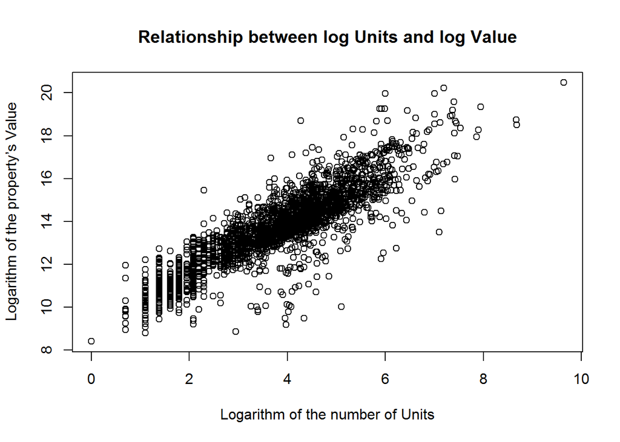

```r
plot(housing$logUnits, housing$logValue, xlab = 'Logarithm of the number of Units', ylab = 'Logarithm of the property’s Value', main = 'Relationship between log Units and log Value')
```

#### (2) Make the same plot as above, but now include the argument col = factor(housing$after1950). Describe this plot and the covariation between the two variables. What does the coloring in the plot tell us?

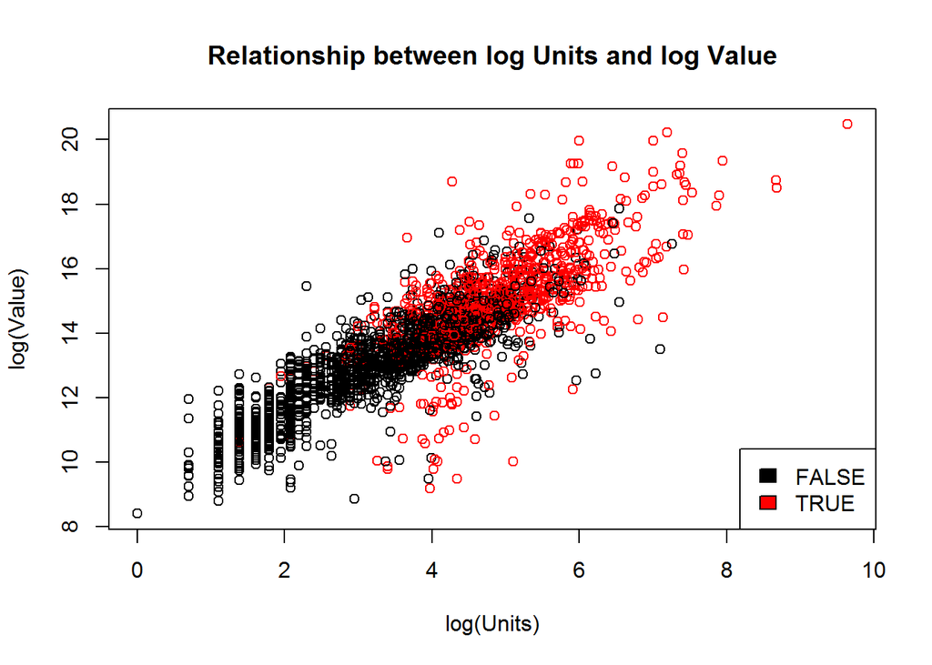

```r
plot(housing$logUnits, housing$logValue, col = factor(housing$after1950), xlab = 'log(Units)', ylab = 'log(Value)', main = 'Relationship between log Units and log Value')
legend("bottomright", legend = levels(factor(housing$after1950)), fill = unique(factor(housing$after1950)))
```

**Answer:** the property was built in or after 1950 have more units and more expensive.

#### (3) The cor() function calculates the correlation coefficient between two variables. What is the correlation between property logValue and property logUnits in (i) the whole data, (ii) just Manhattan (iii) just Brooklyn (iv) for properties built after 1950 (v) for properties built before 1950?

```r
# the whole dataset
cat('the whole dataset ',cor(housing$logValue, housing$logUnits))
```

```
## the whole dataset  0.8727348
```

```r
# just Manhattan
cat('just Manhattan ', cor(housing[housing$Borough == "Manhattan", "logValue"], housing[housing$Borough == "Manhattan", "logUnits"]))
```

```
## just Manhattan  0.8830348
```

```r
# just Brooklyn
cat('just Brooklyn ', cor(housing[housing$Borough == "Brooklyn", "logValue"], housing[housing$Borough == "Brooklyn", "logUnits"]))
```

```
## just Brooklyn  0.9102601
```

```r
# for properties built after 1950
cat('properties built after 1950 ', cor(housing$logValue[housing$YearBuilt > 1950],housing$logUnits[housing$YearBuilt > 1950]))
```

```
## properties built after 1950  0.7285898
```

```r
# for properties built before 1950
cat('properties built before 1950 ', cor(housing$logValue[housing$YearBuilt < 1950],housing$logUnits[housing$YearBuilt < 1950]))
```

```
## properties built before 1950  0.8643297
```

#### (4) Make a single plot showing property logValue against property logUnits for Manhattan and Brooklyn. When creating this plot, clearly distinguish the two boroughs.

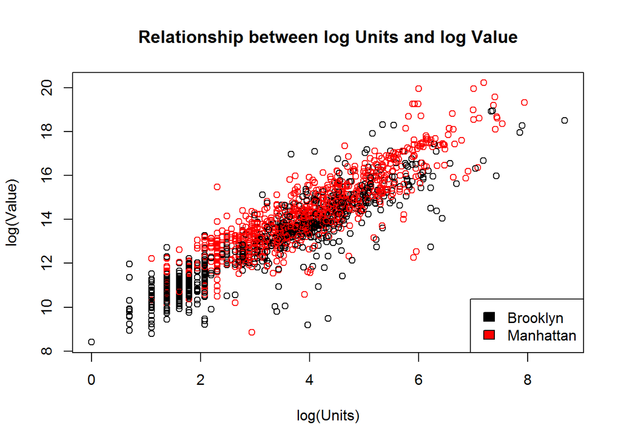

```r
MB_housing = housing[housing$Borough == "Manhattan" | housing$Borough == "Brooklyn", ]
plot(MB_housing$logUnits, MB_housing$logValue, col = factor(MB_housing$Borough), xlab = 'log(Units)', ylab = 'log(Value)', main = 'Relationship between log Units and log Value')
legend("bottomright", legend = levels(factor(MB_housing$Borough)), fill = unique(factor(MB_housing$Borough)))
```

```r
median(housing[housing$Borough == "Manhattan", "Value"],na.rm = TRUE)
```

```
## [1] 1172362
```

#### (6) Make side-by-side box plots comparing property logValue across the five boroughs.

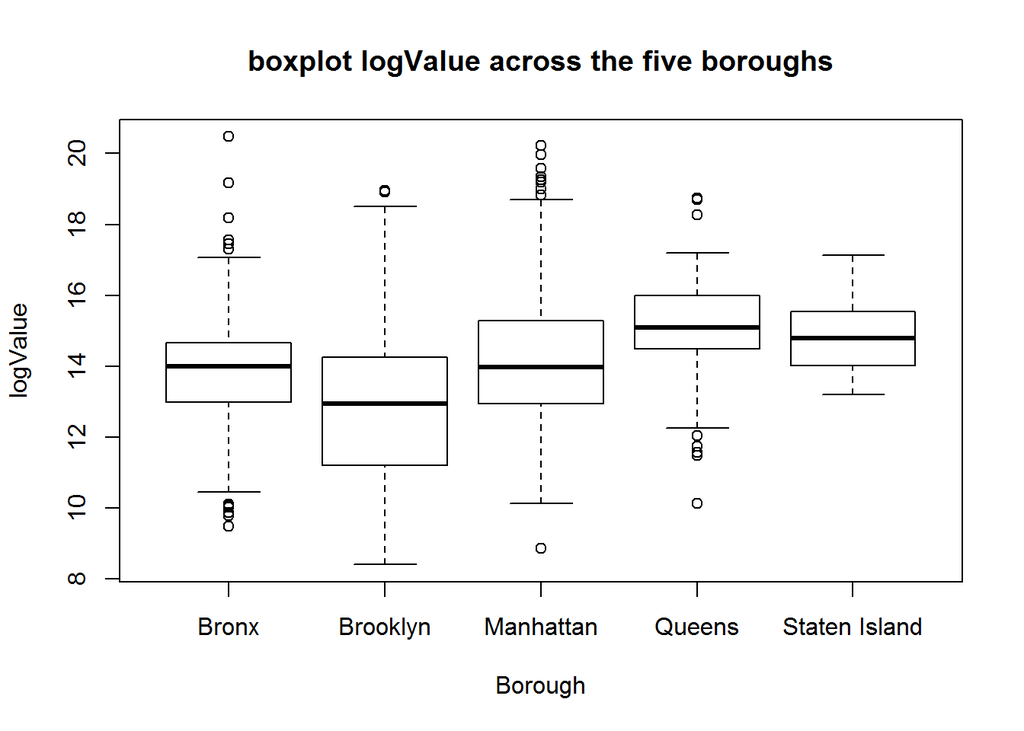

```r
# Boxplot
boxplot(logValue~Borough, data = housing, main = "boxplot logValue across the five boroughs", xlab = "Borough", ylab = "logValue")
```

#### (7) For five boroughs, what are the median property values? (Use Value here, not logValue.)

```r
# method 1
cat('method 1', sep = '\n')
```

```
## method 1
```

```r
tapply(housing$Value, housing$Borough, median)
```

```
##         Bronx      Brooklyn     Manhattan        Queens Staten Island
##       1192950        417610       1172362       3611700       2654100
```

```r
# method 2
cat('method 2', sep = '\n')
```

```
## method 2
```

```r
for (each_borough in unique(housing$Borough)) {
  cat(each_borough, median(housing[housing$Borough == each_borough, "Value"],na.rm = TRUE), sep="\n")
}
```

```
## Bronx
## 1192950
## Brooklyn
## 417610
## Manhattan
## 1172362
## Queens
## 3611700
## Staten Island
## 2654100
```